# Exotic model selection 14

Lia Ossanna

2022-05-24

Analysis for Ossanna & Gornish (2022), “Efficacy of labile carbon addition to reduce exotic invasive plants: A review and meta-analysis”, *Journal of Applied Ecology*.

# Introduction

- Model selection follows [this tutorial](https://www.metafor-project.org/doku.php/tips:model_selection_with_glmulti_and_mumin) from the `metafor` website.
  - Code also adapted from Kinlock 2017 (*Global Ecology and Biogeography*) and Yan 2018 (*Forests*).

## Rationale for moderators included

#### `region`

```r
biome.region <- ex %>%
  select(region, biome)
biome.region <- unique(biome.region)
count(biome.region, biome)
```

```
##                          biome n
## 1            coastal grassland 1
## 2           coastal sage scrub 1
## 3  coastal sandplain grassland 1
## 4                  cold desert 1
## 5               creosote scrub 1
## 6               fescue prairie 1
## 7                       fynbos 1
## 8              grassy woodland 1
## 9          mixed-grass prairie 3
## 10       Puget lowland prairie 1
## 11            sagebrush steppe 3
## 12                sedge meadow 1
## 13        shadscale-bunchgrass 1
## 14           shortgrass steppe 1
## 15           tallgrass prairie 1
## 16              upland prairie 1
## 17             wetland prairie 1
## 18                        <NA> 1
```

```r
count(count(biome.region, biome), n)
```

```
##   n nn
## 1 1 16
## 2 3  2
```

```r
region.biome <- ex %>%
  select(biome, region)
region.biome <- unique(region.biome)
count(region.biome, region)
```

```
##                    region n
## 1          central Canada 2
## 2         coastal CA, USA 2
## 3        Great Basin, USA 3
## 4       Great Plains, USA 2
## 5            Midwest, USA 3
## 6           northeast USA 1
## 7  Pacific Northwest, USA 4
## 8    Rocky Mountains, USA 2
## 9            South Africa 1
## 10    southeast Australia 1
## 11          southwest USA 1
```

```r
count(count(region.biome, region), n)
```

```
##   n nn
## 1 1  4
## 2 2  4
## 3 3  2
## 4 4  1
```

- Almost all `biome` levels contain only one `region` level, but the reverse is not true because there are fewer levels of `region`.

`soil_suborder` was excluded because it gives information redundant to what `region` provides.

```r
soil.region <- ex %>%
  select(region, soil_suborder)
soil.region <- unique(soil.region)
count(soil.region, soil_suborder)
```

```
##        soil_suborder n
## 1            Aqualfs 1
## 2            Aquolls 2
## 3             Argids 3
## 4          Blacktown 1
## 5            Calcids 1
## 6            Cambids 2
## 7         Chernozems 1
## 8            Humults 1
## 9           Orthents 2
## 10 Psamments, Udepts 1
## 11            Udolls 1
## 12            Udults 1
## 13           Ustalfs 2
## 14           Ustepts 1
## 15           Ustolls 3
## 16         Vertisols 1
## 17           Xerands 1
## 18           Xerepts 1
## 19           Xerolls 1
## 20              <NA> 7
```

```r
count(count(soil.region, soil_suborder), n)
```

```
##   n nn
## 1 1 13
## 2 2  4
## 3 3  2
## 4 7  1
```

```r
region.soil <- ex %>%
  select(soil_suborder, region)
region.soil <- unique(region.soil)
count(region.soil, region)
```

```
##                    region n
## 1          central Canada 1
## 2         coastal CA, USA 4
## 3        Great Basin, USA 4
## 4       Great Plains, USA 3
## 5            Midwest, USA 4
## 6           northeast USA 1
## 7  Pacific Northwest, USA 5
## 8    Rocky Mountains, USA 6
## 9            South Africa 1
## 10    southeast Australia 3
## 11          southwest USA 2
```

```r
count(count(region.soil, region), n)
```

```
##   n nn
## 1 1  3
## 2 2  1
## 3 3  2
## 4 4  3
## 5 5  1
## 6 6  1
```

#### `dlc`

- `dlc` was selected in regard to study duration because the single-moderator model analysis revealed it had the highest QM/QT.

#### `C_type`, `cratc`, `plotc`

- `C_type`, `cratc`, and `plotc` were included because they represent unique and important aspects of a study.
- C rate was converted to categorical version for easier interpretation.

#### `capt`

- `capt` was selected in regard to reapplication because it gives some indication of study duration in combination with `dlc`.
- The boxplot below shows the relationship between months applying C (`capt`) and total number of C applications (`C_app`).

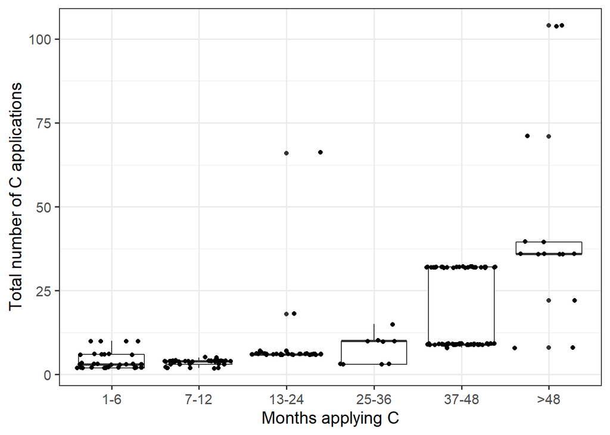

```r
reapp <- ex %>%
  filter(capt != "1 application total")
ggplot(reapp, aes(x = capt, y = C_app)) +
  geom_boxplot() +
  geom_jitter() +
  theme_bw(base_size = 14) +
  xlab("Months applying C") +
  ylab("Total number of C applications")
```

# Setup

```r
library(tidyverse)
library(readxl)
library(metafor)
library(glmulti)

# Load data ---------------------------------------------------------------

raw <- read_xlsx("data/C-addition-studies.xlsx", sheet = "screen 3_data (biocov)")
raw$plant_apgfs <- paste(raw$plant_anper, raw$plant_gfs, sep = " ")
raw$C_app_tm <- raw$duration_first - raw$duration_last
raw$C_app_ma <- raw$C_app_tm / raw$C_app

# Data wrangling
trt.cntrl.se.sd <- c("biomass_mean_trt", "biomass_SE_trt", "biomass_SD_trt",
                     "biomass_mean_cntrl", "biomass_SE_cntrl", "biomass_SD_cntrl")
to.drop <- c("biomass_SE_trt", "biomass_SE_cntrl", "to_sd_trt", "to_sd_cntrl")
biomass <- raw %>%
  select(!(contains("cover"))) %>%
  select(!contains("density")) %>%
  filter(!is.na(biomass_mean_trt)) %>%
  mutate_at(trt.cntrl.se.sd, as.numeric) %>%
  mutate(to_sd_trt = biomass_SE_trt * sqrt(n_trt)) %>%
  mutate(to_sd_cntrl = biomass_SE_cntrl * sqrt(n_cntrl)) %>%
  mutate(biomass_SD_trt = paste(biomass_SD_trt, to_sd_trt)) %>%
  mutate(biomass_SD_trt = str_remove(biomass_SD_trt, pattern = "NA"), .keep = "unused") %>%
  mutate(biomass_SD_cntrl = paste(biomass_SD_cntrl, to_sd_cntrl)) %>%
  mutate(biomass_SD_cntrl = str_remove(biomass_SD_cntrl, pattern = "NA"), .keep = "unused") %>%
  select(-all_of(to.drop)) %>%
  mutate_at(c("biomass_SD_trt", "biomass_SD_cntrl"), as.numeric) %>%
  rename(mean_trt = biomass_mean_trt) %>%
  rename(mean_cntrl = biomass_mean_cntrl) %>%
  rename(SD_trt = biomass_SD_trt) %>%
  rename(SD_cntrl = biomass_SD_cntrl)
biomass$res <- rep("biomass", nrow(biomass))

trt.cntrl.se.sd <- c("cover_mean_trt", "cover_SE_trt", "cover_SD_trt",
                     "cover_mean_cntrl", "cover_SE_cntrl", "cover_SD_cntrl")
to.drop <- c("cover_SE_trt", "cover_SE_cntrl", "to_sd_trt", "to_sd_cntrl")
cover <- raw %>%
  select(!(contains("biomass"))) %>%
  select(!contains("density")) %>%
  filter(!is.na(cover_mean_cntrl)) %>%
  mutate_at(trt.cntrl.se.sd, as.numeric) %>%
  mutate(to_sd_trt = cover_SE_trt * sqrt(n_trt)) %>%
  mutate(to_sd_cntrl = cover_SE_cntrl * sqrt(n_cntrl)) %>%
  mutate(cover_SD_trt = paste(cover_SD_trt, to_sd_trt)) %>%
  mutate(cover_SD_trt = str_remove(cover_SD_trt, pattern = "NA"), .keep = "unused") %>%
  mutate(cover_SD_cntrl = paste(cover_SD_cntrl, to_sd_cntrl)) %>%
  mutate(cover_SD_cntrl = str_remove(cover_SD_cntrl, pattern = "NA"), .keep = "unused") %>%
  select(-all_of(to.drop)) %>%
  mutate_at(c("cover_SD_trt", "cover_SD_cntrl"), as.numeric)  %>%
  rename(mean_trt = cover_mean_trt) %>%
  rename(mean_cntrl = cover_mean_cntrl) %>%
  rename(SD_trt = cover_SD_trt) %>%
  rename(SD_cntrl = cover_SD_cntrl) # warning because one Burke point is blank (was <1)
cover$res <- rep("cover", nrow(cover))

all.1res <- rbind(biomass, cover)


# Calculating effect size -------------------------------------------------

ex <- all.1res %>%
  filter(str_detect(plant_category, "exotic"))

ex <- escalc(measure = "SMD",
             n1i = n_trt,
             n2i = n_cntrl,
             m1i = mean_trt,
             m2i = mean_cntrl,
             sd1i = SD_trt,
             sd2i = SD_cntrl,
             data = ex)

ex <- ex %>%
  filter(!is.na(yi)) # 568 to 488 obs



# Categorical versions ----------------------------------------------------

ex$dfc <- c()
for(i in 1:nrow(ex)) {
  if(ex$duration_first[i] == 3) {
    ex$dfc[i] <- "3"
  } else if(between(ex$duration_first[i], 5, 6)) {
    ex$dfc[i] <- "5-6"
  } else if(between(ex$duration_first[i], 7, 12)) {
    ex$dfc[i] <- "7-12"
  } else if(between(ex$duration_first[i], 12, 18)) {
    ex$dfc[i] <- "12-18"
  } else if(between(ex$duration_first[i], 19, 24)) {
    ex$dfc[i] <- "19-24"
  } else if(between(ex$duration_first[i], 25, 36)) {
    ex$dfc[i] <- "25-36"
  } else if(between(ex$duration_first[i], 37, 50)) {
    ex$dfc[i] <- "37-50"
  } else if(between(ex$duration_first[i], 100, 200)) {
    ex$dfc[i] <- "100-200"
  } else {
    ex$dfc[i] <- ">200"
  }
}
ex$dfc <- factor(ex$df, levels = c("3", "5-6", "7-12", "12-18", "19-24", "25-36", "37-50", "100-200", ">200"))

ex$dlc <- c()
for(i in 1:nrow(ex)) {
  if(between(ex$duration_last[i], 0, 1.5)) {
    ex$dlc[i] <- "0-1.5"
  } else if(ex$duration_last[i] == 2) {
    ex$dlc[i] <- "2"
  } else if(between(ex$duration_last[i], 3, 3.5)) {
    ex$dlc[i] <- "3-3.5"
  } else if(between(ex$duration_last[i], 4, 6)) {
    ex$dlc[i] <- "4-6"
  } else if(between(ex$duration_last[i], 7, 12)) {
    ex$dlc[i] <- "7-12"
  } else if(between(ex$duration_last[i], 13, 18)) {
    ex$dlc[i] <- "13-18"
  } else if(between(ex$duration_last[i], 19, 24)) {
    ex$dlc[i] <- "19-24"
  } else if(between(ex$duration_last[i], 36, 49)) {
    ex$dlc[i] <- "36-49"
  } else {
    ex$dlc[i] <- ">100"
  }
}
ex$dlc <- factor(ex$dl, levels = c("0-1.5", "2", "3-3.5", "4-6", "7-12", "13-18", "19-24",
                                   "36-49", ">100"))

ex$cratc <- c()
for(i in 1:nrow(ex)) {
  if(is.na(ex$C_rate[i])) {
    ex$cratc[i] <- "idk"
  } else if(between(ex$C_rate[i], 0, 100)) {
    ex$cratc[i] <- "30-100"
  } else if(between(ex$C_rate[i], 101, 160)) {
    ex$cratc[i] <- "133-160"
  } else if(between(ex$C_rate[i], 161, 200)) {
    ex$cratc[i] <- "174-200"
  } else if(between(ex$C_rate[i], 201, 300)) {
    ex$cratc[i] <- "210-300"
  } else if(between(ex$C_rate[i], 301, 400)) {
    ex$cratc[i] <- "330-400"
  } else if(between(ex$C_rate[i], 401, 500)) {
    ex$cratc[i] <- "420-500"
  } else if(between(ex$C_rate[i], 501, 600)) {
    ex$cratc[i] <- "506-600"
  } else if(between(ex$C_rate[i], 630, 700)) {
    ex$cratc[i] <- "620-700"
  } else if(between(ex$C_rate[i], 714, 999)) {
    ex$cratc[i] <- "714-999"
  } else if(between(ex$C_rate[i], 1000, 1330)) {
    ex$cratc[i] <- "1000-1330"
  } else if(between(ex$C_rate[i], 1600, 2000)) {
    ex$cratc[i] <- "1600-2000"
  } else if(between(ex$C_rate[i], 2001, 3000)) {
    ex$cratc[i] <- "2110-3000"
  } else if(between(ex$C_rate[i], 3001, 5000)) {
    ex$cratc[i] <- "3346-5000"
  } else {
    ex$cratc[i] <- ">5000"
  }
}
ex$cratc <- factor(ex$cratc, levels = c("30-100", "133-160", "174-200", "210-300", "330-400", "420-500",
                                        "506-600", "620-700", "714-999", "1000-1330", "1600-2000",
                                        "2110-3000", "3346-5000", ">5000"))

ex$capc <- c()
for(i in 1:nrow(ex)) {
  if(ex$C_app[i] == 1) {
    ex$capc[i] <- "1"
  } else if(ex$C_app[i] == 2) {
    ex$capc[i] <- "2"
  } else if(between(ex$C_app[i], 3, 6)) {
    ex$capc[i] <- "3-6"
  } else if(between(ex$C_app[i], 7, 10)) {
    ex$capc[i] <- "7-10"
  } else if(between(ex$C_app[i], 15, 22)) {
    ex$capc[i] <- "15-22"
  } else if(between(ex$C_app[i], 32, 40)) {
    ex$capc[i] <- "32-40"
  } else {
    ex$capc[i] <- ">40"
  }
}
ex$capc <- factor(ex$capc, levels = c("1", "2", "3-6", "7-10", "15-22", "32-40", ">40"))

ex$capm <- c()
for(i in 1:nrow(ex)) {
  if(ex$C_app_ma[i] == 0) {
    ex$capm[i] <- "1 application total"
  } else if(between(ex$C_app_ma[i], 0.001, 1)) {
    ex$capm[i] <- "<1"
  } else if(between(ex$C_app_ma[i], 1.001, 2)) {
    ex$capm[i] <- "1-2"
  } else if(between(ex$C_app_ma[i], 2.001, 4)) {
    ex$capm[i] <- "2-4"
  } else {
    ex$capm[i] <- "4-11"
  }
}
ex$capm <- factor(ex$capm, levels = c("1 application total", "<1", "1-2", "2-4", "4-11"))

ex$capt <- c()
for(i in 1:nrow(ex)) {
  if(ex$C_app_tm[i] == 0) {
    ex$capt[i] <- "1 application total"
  } else if(between(ex$C_app_tm[i], 0.001, 6)) {
    ex$capt[i] <- "1-6"
  } else if(between(ex$C_app_tm[i], 7, 12)) {
    ex$capt[i] <- "7-12"
  } else if(between(ex$C_app_tm[i], 13, 24)) {
    ex$capt[i] <- "13-24"
  } else if(between(ex$C_app_tm[i], 25, 36)) {
    ex$capt[i] <- "25-36"
  } else if(between(ex$C_app_tm[i], 37, 48)) {
    ex$capt[i] <- "37-48"
  } else {
    ex$capt[i] <- ">48"
  }
}
ex$capt <- factor(ex$capt, levels = c("1 application total", "1-6", "7-12", "13-24",
                                      "25-36", "37-48", ">48"))

ex$plotc <- c()
for(i in 1:nrow(ex)) {
  if(is.na(ex$plot[i])) {
    ex$plotc[i] <- "idk"
  } else if(ex$plot[i] < 1) {
    ex$plotc[i] <- "<1"
  } else if(ex$plot[i] == 1) {
    ex$plotc[i] <- "1"
  } else if(between(ex$plot[i], 1.3, 3.75)) {
    ex$plotc[i] <- "1.3-3.75"
  } else if(ex$plot[i] == 4) {
    ex$plotc[i] <- "4"
  } else if(between(ex$plot[i], 6, 9)) {
    ex$plotc[i] <- "6-9"
  } else if(ex$plot[i] == 12) {
    ex$plotc[i] <- "12"
  } else if(between(ex$plot[i], 12.5, 16)) {
    ex$plotc[i] <- "12.5-16"
  } else if(ex$plot[i] == 25) {
    ex$plotc[i] <- "25"
  } else if(between(ex$plot[i], 28, 50)) {
    ex$plotc[i] <- "28-50"
  } else if(ex$plot[i] == 75) {
    ex$plotc[i] <- "75"
  } else {
    ex$plotc[i] <- ">100"
  }
}
ex$plotc <- factor(ex$plotc,
                   levels = c("<1", "1", "1.3-3.75", "4", "6-9", "12", "12.5-16",
                              "25", "28-50", "75", ">100"))


# Model selection setup ---------------------------------------------------

rma.glmulti <- function(formula, data, V, random,...) {
  do.call("rma.mv", list(as.formula(paste(deparse(formula))), V = as.name(V), random = as.name(random), data = data,  method = "ML", ...))
}
rand <- list(~ 1 | obs_ID, ~ 1 | exp_ID)


# Multimodel inference
eval(metafor:::.glmulti)
```

# 14: `region`, `dlc`, `C_type`, `cratc`, `capt`, `plant_apgfs`, `plotc`

- Model had no outliers.

```r
ex.ms14 <- ex[!apply(ex[ , c("region", "dlc", "C_type", "cratc", "capt", "plant_apgfs", "plotc")], 1, anyNA), ]

res14 <- glmulti(yi ~ region + dlc + C_type + cratc + capt + plant_apgfs + plotc,
                  V = "vi", data = ex.ms14, level = 1, fitfunction = rma.glmulti,
                  random = "rand", crit = "aicc")
```

```r
print(res14)
```

[output not shown]

```r
# Models within 2 AICc units
top <- weightable(res14)
top <- top[top$aicc <= min(top$aicc) + 2, ]
top
```

```
##                                         model     aicc   weights
## 1 yi ~ 1 + dlc + plotc + region + plant_apgfs 1286.618 0.9369876
```

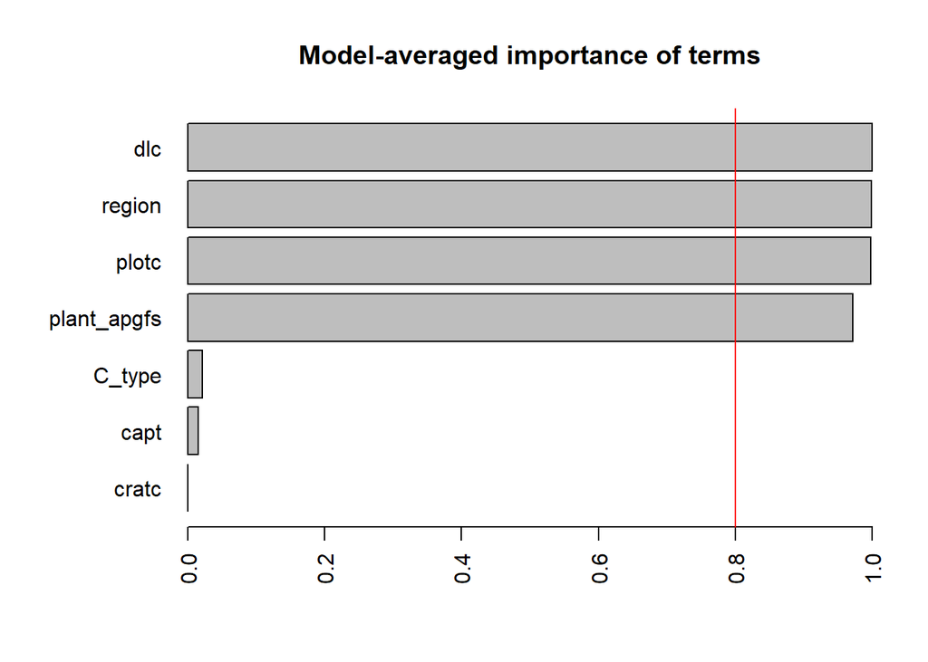

```r
plot(res14, type = "s")
```

```r
# Top 5 models
weightable(res14)[1:5, ]
```

```
##                                                  model     aicc     weights
## 1          yi ~ 1 + dlc + plotc + region + plant_apgfs 1286.618 0.936987609
## 2                        yi ~ 1 + dlc + plotc + region 1293.694 0.027245872
## 3 yi ~ 1 + dlc + plotc + region + C_type + plant_apgfs 1294.282 0.020301234
## 4   yi ~ 1 + dlc + capt + plotc + region + plant_apgfs 1295.324 0.012060929
## 5           yi ~ 1 + dlc + capt + region + plant_apgfs 1300.011 0.001157534
```

## Top model 1

```r
summary(res14@objects[[1]])
```

```
##
## Multivariate Meta-Analysis Model (k = 466; method: ML)
##
##    logLik   Deviance        AIC        BIC       AICc
## -600.6472   690.6898  1279.2944  1440.9176  1286.6183
##
## Variance Components:
##
##             estim    sqrt  nlvls  fixed  factor
## sigma^2.1  0.0833  0.2887    466     no  obs_ID
## sigma^2.2  0.0000  0.0000     44     no  exp_ID
##
## Test for Residual Heterogeneity:
## QE(df = 429) = 699.7376, p-val < .0001
##
## Test of Moderators (coefficients 2:37):
## QM(df = 36) = 254.5569, p-val < .0001
##
## Model Results:
##
##                                 estimate      se     zval    pval    ci.lb
## intrcpt                          -1.1296  0.6157  -1.8347  0.0665  -2.3364
## dlc2                              0.6782  0.3011   2.2525  0.0243   0.0881
## dlc3-3.5                          0.9746  0.2637   3.6962  0.0002   0.4578
## dlc4-6                            0.4194  0.3845   1.0907  0.2754  -0.3342
## dlc7-12                           1.0334  0.3286   3.1448  0.0017   0.3894
## dlc13-18                          1.4429  0.2663   5.4190  <.0001   0.9210
## dlc19-24                          2.6204  0.5935   4.4155  <.0001   1.4573
## dlc36-49                          1.7064  0.3389   5.0352  <.0001   1.0422
## dlc>100                          -0.3591  0.5906  -0.6080  0.5432  -1.5167
## plotc1                           -0.6361  0.3320  -1.9159  0.0554  -1.2869
## plotc1.3-3.75                     0.4863  0.4498   1.0812  0.2796  -0.3952
## plotc4                            1.3823  0.6348   2.1775  0.0294   0.1381
## plotc6-9                          0.8680  0.5131   1.6917  0.0907  -0.1377
## plotc12                           0.4183  0.4899   0.8539  0.3932  -0.5418
## plotc12.5-16                      1.4816  0.5334   2.7779  0.0055   0.4363
## plotc25                           1.4382  0.5174   2.7797  0.0054   0.4241
## plotc28-50                        0.3061  0.6359   0.4814  0.6302  -0.9403
## plotc75                           0.5764  0.5902   0.9765  0.3288  -0.5805
## plotc>100                         3.1214  0.6925   4.5075  <.0001   1.7641
```

[output cut: 44 more lines]

```
## regionRocky Mountains, USA       0.7910
## regionsoutheast Australia       -0.2784    *
## regionsouthwest USA              0.1318    .
## plant_apgfsannual graminoid      0.3035
## plant_apgfsbiennial forb         0.5511
## plant_apgfsperennial forb        0.6609   **
## plant_apgfsperennial graminoid   0.4157
## plant_apgfsperennial shrub       1.3732
## plant_apgfsunknown forb          0.5797
## plant_apgfsunknown graminoid    -0.2098   **
## plant_apgfsunknown shrub         1.2051
## plant_apgfsunknown unknown       1.3316    *
##
## ---
## Signif. codes:  0 '***' 0.001 '**' 0.01 '*' 0.05 '.' 0.1 ' ' 1
```

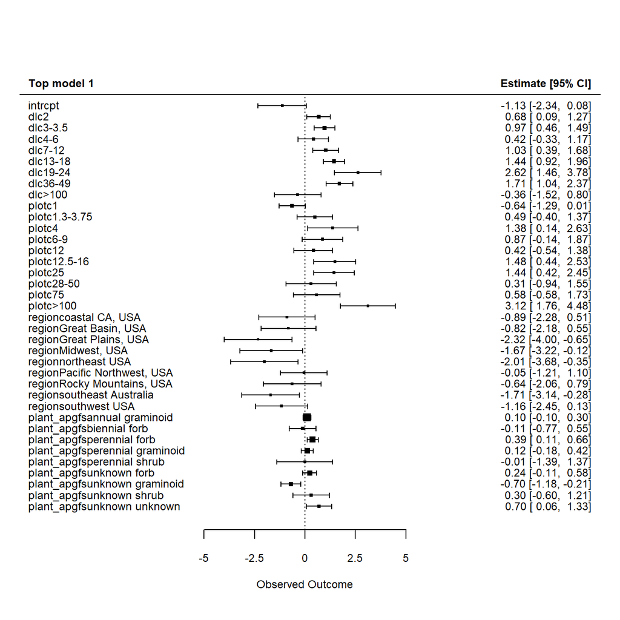

```r
forest(x = res14@objects[[1]]$b,
       ci.lb = res14@objects[[1]]$ci.lb,
       ci.ub = res14@objects[[1]]$ci.ub,
       slab = rownames(res14@objects[[1]]$b),
       alim = c(-5, 5),
       header = c("Top model 1", "Estimate [95% CI]"),
       cex = 0.75)
```

# Multimodel inference

- Multimodel inference is not necessary because there is only 1 top model (no others within 2 AICc units).